# subpopulatoin analysis

# Summary

This notebook performs simple exploratory data analysis for single-cell EMT data. Some of the code was adapted from various sources.

# 1. Download all libraries and library dependencies

First, we’ll download several libraries and library dependencies for single-cell data processing and data visualization.

Note that the following codeblock takes awhile to run. Only do it if you do not have the libraries pre-installed in your R environment.

```r
#pkgLst = c("Seurat", "dplyr", "viridis",
#           "matrixStats", "UpSetR",
#           "mgcv", "tidyverse", "reshape2", "ggplot2")
#install.packages(pkgLst)

library(mgcv)
library(splines)
library(Seurat)
library(dplyr)
library(tidyr)
library(viridis)
library(matrixStats)
library(UpSetR)
library(reshape2)
library(ggplot2)
library(Rmagic)
```

# 2. Load A549 TGF-B dataset

First, let’s load up the data from A549.

```r
rm(list=ls())
#datapath = "C:/Users/scott/Data/scRNASeq/GSE147405/A549/A549_TGFB1.rds"
datapath = "D:/Data/scRNASeq/GSE147405/A549/A549_TGFB1.rds"
a549_tgfb = readRDS(datapath)
unique(a549_tgfb@meta.data$Time)
```

```
[1] "3d"    "7d"    "1d"    "1d_rm" "8h_rm" "3d_rm" "8h"    "0d"
```

## Filter genes

Let’s filter out some low quality genes.

```r
genes_filter = rownames(a549_tgfb[["RNA"]]@data)[rowSums(as.matrix(a549_tgfb[["RNA"]]@data)) > 0]
a549_tgfb = subset(a549_tgfb, features=genes_filter)
```

## Regress out cell cycle

We can regress some biological variance out, including cell cycle genes.

```r
genes_to_regress = "D:/Data/scRNASeq/GSE147405/regev_lab_cell_cycle_genes.txt"
cc.genes = readLines(con=genes_to_regress)
```

```
incomplete final line found on 'D:/Data/scRNASeq/GSE147405/regev_lab_cell_cycle_genes.txt'
```

```r
s.genes  = cc.genes[1:43]
g2m.genes = cc.genes[44:97]
a549_tgfb = CellCycleScoring(a549_tgfb,
                             s.features=s.genes,
                             g2m.features=g2m.genes,
                             set.ident=FALSE)
```

```
The following features are not present in the object: MLF1IP, not searching for symbol synonyms
```

## Subset time points of interest

Finally, let’s subset out some of the cells.

```r
a549_tgfb = subset(a549_tgfb, subset = Time==c("0d", "8h", "3d", "1d", "7d"))
```

```
longer object length is not a multiple of shorter object length
```

## Preprocess data for MAGIC

Now, we’ll run MAGIC on the dataset.

```r
data = data.frame(a549_tgfb@assays$RNA@counts)
data = t(data)
```

Ensure our initial filtering worked.

```r
# keep genes expressed in at least 10 cells
keep_cols = colSums(data > 0) > 10
data = data[,keep_cols]
```

Plot the data distribution.

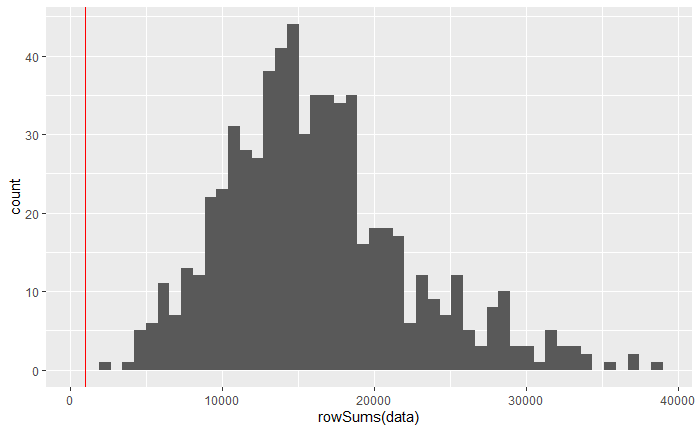

```r
# look at the distribution of library sizes
ggplot() +
  geom_histogram(aes(x=rowSums(data)), bins=50) +
  geom_vline(xintercept = 1000, color='red')
```

```r
a549_magic = magic(data)
```

[output not shown]

[output not shown]

```r
yes
```

[output not shown]

```r
1
```

[output not shown]

After this, all we have to do is run the dataset through MAGIC in Python.

```r
write.table(data, file="D:/Analysis/EMT/a549_tgfb_preprocessed_for_magic.csv",
            row.names=TRUE, col.names=TRUE)
```

# 3. Data preprocessing

```r
a549_tgfb = find_subpopulations(a549_tgfb)
cluster_pred = a549_tgfb@active.ident
```

```r
a549_tgfb@active.ident = as.factor(a549_tgfb@meta.data$Time)
DimPlot(a549_tgfb,
        reduction="umap",
        dims=c(1, 2),
        #cols=c("#4477AA", "#228833", "#AA3377", "#EE6677"),
        label=TRUE,
        repel=TRUE,
        label.size=4,
        pt.size=1.5,
        na.value = "grey50") +
        labs(title="",
             x="UMAP 1",
             y="UMAP 2") +
        theme_minimal() +
        theme(plot.title = element_text(size=10),
              legend.text=element_text(size=8),
              axis.title.x=element_text(size=10),
              axis.title.y=element_text(size=10),
              axis.text.x=element_text(size=8),
              axis.text.y=element_text(size=8),
              legend.position=c(0.15, 0.15),
              legend.box="vertical",
              legend.margin=margin(),
              text=element_text(family="sans")) +
        guides(color=guide_legend(override.aes=list(size=2)))

a549_tgfb@active.ident = cluster_pred
DimPlot(a549_tgfb,
        reduction="umap",
        dims=c(1, 2),
        #cols=c("#4477AA", "#228833", "#AA3377", "#EE6677"),
        label=TRUE,
        repel=TRUE,
        label.size=4,
        pt.size=1.5,
        na.value = "grey50") +
        labs(title="",
             x="UMAP 1",
             y="UMAP 2") +
        theme_minimal() +
        theme(plot.title = element_text(size=10),
              legend.text=element_text(size=8),
              axis.title.x=element_text(size=10),
              axis.title.y=element_text(size=10),
              axis.text.x=element_text(size=8),
              axis.text.y=element_text(size=8),
              legend.position=c(0.15, 0.15),
              legend.box="vertical",
              legend.margin=margin(),
              text=element_text(family="sans")) +
        guides(color=guide_legend(override.aes=list(size=2)))
```

[output not shown]

# 4. Load metabolic flux data

We’ll read in the metabolic flux data computed from single-cell Flux Balance Analysis

```r
path_to_neutrophil_flux = 'D:/Analysis/EMT/recon1_cobra_results.xlsx'
sheet_name = 'Flux'
flux_data = read_excel(path_to_neutrophil_flux, sheet_name)
rxn_ids = flux_data[, 1:3]
flux_data[, 1:3] = NULL
row.names(flux_data) = rxn_ids$ID
```

```r
flux_data = t(flux_data)
#flux_data[, 2:ncol(flux_data)] = abs(flux_data[, 2:ncol(flux_data)])
```

```r
ids =read_csv(path_to_old_ids)
```

First, we’ll grab the day number,

```r
# Grab day
```

```r
ids$day = ids$X3
```

Then add a count to the end of that particular time point. Also, reformat it so that it looks like the old mapping.

```r
# Iteratively add 1 for all duplicates
ids$day = as.numeric(ids$day)
ids$day = ids$day * 10
ids = data.frame(ids)
ids$new_day = ave(ids$day, ids$X3, FUN = function(x) x[1] + seq_along(x) - 1)
ids$new_day = ids$new_day - ids$day
ids$day = ids$day / 10
```

We have to now merge the ids and the metabolic flux data to get a cohesive mapping of cell identifiers to flux.

```r
mapped_flux = merge(ids,
                    flux_data,
                    by.x='final_col',
                    by.y='row.names')
```

## A. Format FBA Data

Now we need to make sure the expression matrix has the same cells as the fba matrix, and also ensure the `active.ident` and the `Time` datapoints we’ll map to.

```r
# Get names and indices
intersect_cells = intersect(colnames(neut@assays$RNA@counts), colnames(fba))
```

## B. Create FBA Assay in Seurat Object

This incorporates FBA into the Seurat Object.

```r
a549_tgfb[["FBA"]] = CreateAssayObject(counts=fba)
```

## C. Perform data preprocessing for metabolic fluxes

```r
preprocess_flux = function(gene_obj, assay){
  # Log normalize data
  #gene_obj = NormalizeData(gene_obj,
  #                         assay=assay,
  #                         normalization.method='LogNormalize',
  #                         scale.factor=10000)

  # Scale data
  #gene_obj = ScaleData(gene_obj,
  #                     assay=assay)

  gene_obj = SCTransform(gene_obj)
  return(gene_obj)
}
```

Now let’s perform the data preprocessing:

```r
a549_tgfb = preprocess_flux(a549_tgfb, assay="FBA")
```

```r
subpop_reactions = FindAllMarkers(a549_tgfb,
                                  assay="RNA")
```